# Combining dataframes and scraping Canadian weather data

By the end of this chapter, we're going to have downloaded all of Canada's weather data for 2012, and saved it to a CSV.

Here's the temperature every hour for 2012!

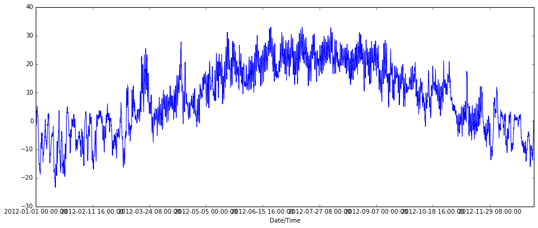

```python
weather_2012_final = pd.read_csv('../data/weather_2012.csv', index_col='Date/Time')
weather_2012_final['Temp (C)'].plot(figsize=(15, 6))
```

# 5.1 Downloading one month of weather data

When playing with the cycling data, I wanted temperature and precipitation data to find out if people like biking when it's raining. So I went to the site for [Canadian historical weather data](http://climate.weather.gc.ca/index_e.html#access), and figured out how to get it automatically.

Here we're going to get the data for March 2012, and clean it up

Here's an URL template you can use to get data in Montreal.

```python
url_template = "http://climate.weather.gc.ca/climate_data/bulk_data_e.html?format=csv&stationID=5415&Year={year}&Month={month}&timeframe=1"
# url_template = "http://climate.weather.gc.ca/climate_data/bulk_data_e.html?timeframe=1&Year={year}&Month={month}&StationID=5415&format=csv"
```

```python
url = url_template.format(month=3, year=2012)

try:
    weather_mar2012 = pd.read_csv(url, skiprows=15, index_col='Date/Time', parse_dates=True, encoding='latin1', header=True)
except:
    weather_mar2012 = pd.read_csv('../data/weather_2012.csv', parse_dates=True)
```

This is super great! We can just use the same `read_csv` function as before, and just give it a URL as a filename. Awesome.

```python
weather_mar2012
```

|  | Date/Time | Temp (C) | Dew Point Temp (C) | Rel Hum (%) | Wind Spd (km/h) | Visibility (km) | Stn Press (kPa) | Weather |
| --- | --- | --- | --- | --- | --- | --- | --- | --- |
| 0 | 2012-01-01 00:00:00 | -1.8 | -3.9 | 86 | 4 | 8.0 | 101.24 | Fog |
| 1 | 2012-01-01 01:00:00 | -1.8 | -3.7 | 87 | 4 | 8.0 | 101.24 | Fog |
| 2 | 2012-01-01 02:00:00 | -1.8 | -3.4 | 89 | 7 | 4.0 | 101.26 | Freezing Drizzle,Fog |
| 3 | 2012-01-01 03:00:00 | -1.5 | -3.2 | 88 | 6 | 4.0 | 101.27 | Freezing Drizzle,Fog |
| 4 | 2012-01-01 04:00:00 | -1.5 | -3.3 | 88 | 7 | 4.8 | 101.23 | Fog |
| 5 | 2012-01-01 05:00:00 | -1.4 | -3.3 | 87 | 9 | 6.4 | 101.27 | Fog |
| 6 | 2012-01-01 06:00:00 | -1.5 | -3.1 | 89 | 7 | 6.4 | 101.29 | Fog |
| 7 | 2012-01-01 07:00:00 | -1.4 | -3.6 | 85 | 7 | 8.0 | 101.26 | Fog |
| 8 | 2012-01-01 08:00:00 | -1.4 | -3.6 | 85 | 9 | 8.0 | 101.23 | Fog |
| 9 | 2012-01-01 09:00:00 | -1.3 | -3.1 | 88 | 15 | 4.0 | 101.20 | Fog |
| 10 | 2012-01-01 10:00:00 | -1.0 | -2.3 | 91 | 9 | 1.2 | 101.15 | Fog |
| 11 | 2012-01-01 11:00:00 | -0.5 | -2.1 | 89 | 7 | 4.0 | 100.98 | Fog |
| 12 | 2012-01-01 12:00:00 | -0.2 | -2.0 | 88 | 9 | 4.8 | 100.79 | Fog |
| 13 | 2012-01-01 13:00:00 | 0.2 | -1.7 | 87 | 13 | 4.8 | 100.58 | Fog |
| 14 | 2012-01-01 14:00:00 | 0.8 | -1.1 | 87 | 20 | 4.8 | 100.31 | Fog |
| 15 | 2012-01-01 15:00:00 | 1.8 | -0.4 | 85 | 22 | 6.4 | 100.07 | Fog |
| 16 | 2012-01-01 16:00:00 | 2.6 | -0.2 | 82 | 13 | 12.9 | 99.93 | Mostly Cloudy |
| 17 | 2012-01-01 17:00:00 | 3.0 | 0.0 | 81 | 13 | 16.1 | 99.81 | Cloudy |
| 18 | 2012-01-01 18:00:00 | 3.8 | 1.0 | 82 | 15 | 12.9 | 99.74 | Rain |
| 19 | 2012-01-01 19:00:00 | 3.1 | 1.3 | 88 | 15 | 12.9 | 99.68 | Rain |
| 20 | 2012-01-01 20:00:00 | 3.2 | 1.3 | 87 | 19 | 25.0 | 99.50 | Cloudy |
| 21 | 2012-01-01 21:00:00 | 4.0 | 1.7 | 85 | 20 | 25.0 | 99.39 | Cloudy |
| 22 | 2012-01-01 22:00:00 | 4.4 | 1.9 | 84 | 24 | 19.3 | 99.32 | Rain Showers |
| 23 | 2012-01-01 23:00:00 | 5.3 | 2.0 | 79 | 30 | 25.0 | 99.31 | Cloudy |
| 24 | 2012-01-02 00:00:00 | 5.2 | 1.5 | 77 | 35 | 25.0 | 99.26 | Rain Showers |
| 25 | 2012-01-02 01:00:00 | 4.6 | 0.0 | 72 | 39 | 25.0 | 99.26 | Cloudy |
| 26 | 2012-01-02 02:00:00 | 3.9 | -0.9 | 71 | 32 | 25.0 | 99.26 | Mostly Cloudy |
| 27 | 2012-01-02 03:00:00 | 3.7 | -1.5 | 69 | 33 | 25.0 | 99.30 | Mostly Cloudy |
| 28 | 2012-01-02 04:00:00 | 2.9 | -2.3 | 69 | 32 | 25.0 | 99.26 | Mostly Cloudy |
| 29 | 2012-01-02 05:00:00 | 2.6 | -2.3 | 70 | 32 | 25.0 | 99.21 | Mostly Cloudy |
| ... | ... | ... | ... | ... | ... | ... | ... | ... |
| 8754 | 2012-12-30 18:00:00 | -12.6 | -16.0 | 76 | 24 | 25.0 | 101.36 | Mainly Clear |
| 8755 | 2012-12-30 19:00:00 | -13.4 | -16.5 | 77 | 26 | 25.0 | 101.47 | Mainly Clear |
| 8756 | 2012-12-30 20:00:00 | -13.8 | -16.5 | 80 | 24 | 25.0 | 101.52 | Clear |
| 8757 | 2012-12-30 21:00:00 | -13.8 | -16.5 | 80 | 20 | 25.0 | 101.50 | Mainly Clear |
| 8758 | 2012-12-30 22:00:00 | -13.7 | -16.3 | 81 | 19 | 25.0 | 101.54 | Mainly Clear |
| 8759 | 2012-12-30 23:00:00 | -12.1 | -15.1 | 78 | 28 | 25.0 | 101.52 | Mostly Cloudy |
| 8760 | 2012-12-31 00:00:00 | -11.1 | -14.4 | 77 | 26 | 25.0 | 101.51 | Cloudy |
| 8761 | 2012-12-31 01:00:00 | -10.7 | -14.0 | 77 | 15 | 25.0 | 101.50 | Cloudy |
| 8762 | 2012-12-31 02:00:00 | -10.1 | -13.4 | 77 | 9 | 25.0 | 101.45 | Cloudy |
| 8763 | 2012-12-31 03:00:00 | -11.8 | -14.4 | 81 | 6 | 25.0 | 101.42 | Mostly Cloudy |
| 8764 | 2012-12-31 04:00:00 | -10.5 | -12.8 | 83 | 11 | 25.0 | 101.34 | Cloudy |
| 8765 | 2012-12-31 05:00:00 | -10.2 | -12.4 | 84 | 6 | 25.0 | 101.28 | Cloudy |
| 8766 | 2012-12-31 06:00:00 | -9.7 | -11.7 | 85 | 4 | 25.0 | 101.23 | Cloudy |
| 8767 | 2012-12-31 07:00:00 | -9.3 | -11.3 | 85 | 0 | 19.3 | 101.19 | Snow Showers |
| 8768 | 2012-12-31 08:00:00 | -8.6 | -10.3 | 87 | 4 | 3.2 | 101.14 | Snow Showers |
| 8769 | 2012-12-31 09:00:00 | -8.1 | -9.6 | 89 | 4 | 2.4 | 101.09 | Snow |
| 8770 | 2012-12-31 10:00:00 | -7.4 | -8.9 | 89 | 4 | 6.4 | 101.05 | Snow,Fog |
| 8771 | 2012-12-31 11:00:00 | -6.7 | -7.9 | 91 | 9 | 9.7 | 100.93 | Snow |
| 8772 | 2012-12-31 12:00:00 | -5.8 | -7.5 | 88 | 4 | 12.9 | 100.78 | Snow |
| 8773 | 2012-12-31 13:00:00 | -4.6 | -6.6 | 86 | 4 | 12.9 | 100.63 | Snow |
| 8774 | 2012-12-31 14:00:00 | -3.4 | -5.7 | 84 | 6 | 11.3 | 100.57 | Snow |
| 8775 | 2012-12-31 15:00:00 | -2.3 | -4.6 | 84 | 9 | 9.7 | 100.47 | Snow |
| 8776 | 2012-12-31 16:00:00 | -1.4 | -4.0 | 82 | 13 | 12.9 | 100.40 | Snow |
| 8777 | 2012-12-31 17:00:00 | -1.1 | -3.3 | 85 | 19 | 9.7 | 100.30 | Snow |
| 8778 | 2012-12-31 18:00:00 | -1.3 | -3.1 | 88 | 17 | 9.7 | 100.19 | Snow |
| 8779 | 2012-12-31 19:00:00 | 0.1 | -2.7 | 81 | 30 | 9.7 | 100.13 | Snow |
| 8780 | 2012-12-31 20:00:00 | 0.2 | -2.4 | 83 | 24 | 9.7 | 100.03 | Snow |
| 8781 | 2012-12-31 21:00:00 | -0.5 | -1.5 | 93 | 28 | 4.8 | 99.95 | Snow |
| 8782 | 2012-12-31 22:00:00 | -0.2 | -1.8 | 89 | 28 | 9.7 | 99.91 | Snow |
| 8783 | 2012-12-31 23:00:00 | 0.0 | -2.1 | 86 | 30 | 11.3 | 99.89 | Snow |

8784 rows × 8 columns

```python
weather_mar2012.set_index('Date/Time', inplace=True)
weather_mar2012.index = pd.to_datetime(weather_mar2012.index)
weather_mar2012
```

| Date/Time | Temp (C) | Dew Point Temp (C) | Rel Hum (%) | Wind Spd (km/h) | Visibility (km) | Stn Press (kPa) | Weather |
| --- | --- | --- | --- | --- | --- | --- | --- |
| 2012-01-01 00:00:00 | -1.8 | -3.9 | 86 | 4 | 8.0 | 101.24 | Fog |
| 2012-01-01 01:00:00 | -1.8 | -3.7 | 87 | 4 | 8.0 | 101.24 | Fog |
| 2012-01-01 02:00:00 | -1.8 | -3.4 | 89 | 7 | 4.0 | 101.26 | Freezing Drizzle,Fog |
| 2012-01-01 03:00:00 | -1.5 | -3.2 | 88 | 6 | 4.0 | 101.27 | Freezing Drizzle,Fog |
| 2012-01-01 04:00:00 | -1.5 | -3.3 | 88 | 7 | 4.8 | 101.23 | Fog |
| 2012-01-01 05:00:00 | -1.4 | -3.3 | 87 | 9 | 6.4 | 101.27 | Fog |
| 2012-01-01 06:00:00 | -1.5 | -3.1 | 89 | 7 | 6.4 | 101.29 | Fog |
| 2012-01-01 07:00:00 | -1.4 | -3.6 | 85 | 7 | 8.0 | 101.26 | Fog |
| 2012-01-01 08:00:00 | -1.4 | -3.6 | 85 | 9 | 8.0 | 101.23 | Fog |
| 2012-01-01 09:00:00 | -1.3 | -3.1 | 88 | 15 | 4.0 | 101.20 | Fog |
| 2012-01-01 10:00:00 | -1.0 | -2.3 | 91 | 9 | 1.2 | 101.15 | Fog |
| 2012-01-01 11:00:00 | -0.5 | -2.1 | 89 | 7 | 4.0 | 100.98 | Fog |
| 2012-01-01 12:00:00 | -0.2 | -2.0 | 88 | 9 | 4.8 | 100.79 | Fog |
| 2012-01-01 13:00:00 | 0.2 | -1.7 | 87 | 13 | 4.8 | 100.58 | Fog |
| 2012-01-01 14:00:00 | 0.8 | -1.1 | 87 | 20 | 4.8 | 100.31 | Fog |
| 2012-01-01 15:00:00 | 1.8 | -0.4 | 85 | 22 | 6.4 | 100.07 | Fog |
| 2012-01-01 16:00:00 | 2.6 | -0.2 | 82 | 13 | 12.9 | 99.93 | Mostly Cloudy |
| 2012-01-01 17:00:00 | 3.0 | 0.0 | 81 | 13 | 16.1 | 99.81 | Cloudy |
| 2012-01-01 18:00:00 | 3.8 | 1.0 | 82 | 15 | 12.9 | 99.74 | Rain |
| 2012-01-01 19:00:00 | 3.1 | 1.3 | 88 | 15 | 12.9 | 99.68 | Rain |
| 2012-01-01 20:00:00 | 3.2 | 1.3 | 87 | 19 | 25.0 | 99.50 | Cloudy |
| 2012-01-01 21:00:00 | 4.0 | 1.7 | 85 | 20 | 25.0 | 99.39 | Cloudy |
| 2012-01-01 22:00:00 | 4.4 | 1.9 | 84 | 24 | 19.3 | 99.32 | Rain Showers |
| 2012-01-01 23:00:00 | 5.3 | 2.0 | 79 | 30 | 25.0 | 99.31 | Cloudy |
| 2012-01-02 00:00:00 | 5.2 | 1.5 | 77 | 35 | 25.0 | 99.26 | Rain Showers |
| 2012-01-02 01:00:00 | 4.6 | 0.0 | 72 | 39 | 25.0 | 99.26 | Cloudy |
| 2012-01-02 02:00:00 | 3.9 | -0.9 | 71 | 32 | 25.0 | 99.26 | Mostly Cloudy |
| 2012-01-02 03:00:00 | 3.7 | -1.5 | 69 | 33 | 25.0 | 99.30 | Mostly Cloudy |
| 2012-01-02 04:00:00 | 2.9 | -2.3 | 69 | 32 | 25.0 | 99.26 | Mostly Cloudy |
| 2012-01-02 05:00:00 | 2.6 | -2.3 | 70 | 32 | 25.0 | 99.21 | Mostly Cloudy |
| ... | ... | ... | ... | ... | ... | ... | ... |
| 2012-12-30 18:00:00 | -12.6 | -16.0 | 76 | 24 | 25.0 | 101.36 | Mainly Clear |
| 2012-12-30 19:00:00 | -13.4 | -16.5 | 77 | 26 | 25.0 | 101.47 | Mainly Clear |
| 2012-12-30 20:00:00 | -13.8 | -16.5 | 80 | 24 | 25.0 | 101.52 | Clear |
| 2012-12-30 21:00:00 | -13.8 | -16.5 | 80 | 20 | 25.0 | 101.50 | Mainly Clear |
| 2012-12-30 22:00:00 | -13.7 | -16.3 | 81 | 19 | 25.0 | 101.54 | Mainly Clear |
| 2012-12-30 23:00:00 | -12.1 | -15.1 | 78 | 28 | 25.0 | 101.52 | Mostly Cloudy |
| 2012-12-31 00:00:00 | -11.1 | -14.4 | 77 | 26 | 25.0 | 101.51 | Cloudy |
| 2012-12-31 01:00:00 | -10.7 | -14.0 | 77 | 15 | 25.0 | 101.50 | Cloudy |
| 2012-12-31 02:00:00 | -10.1 | -13.4 | 77 | 9 | 25.0 | 101.45 | Cloudy |
| 2012-12-31 03:00:00 | -11.8 | -14.4 | 81 | 6 | 25.0 | 101.42 | Mostly Cloudy |
| 2012-12-31 04:00:00 | -10.5 | -12.8 | 83 | 11 | 25.0 | 101.34 | Cloudy |
| 2012-12-31 05:00:00 | -10.2 | -12.4 | 84 | 6 | 25.0 | 101.28 | Cloudy |
| 2012-12-31 06:00:00 | -9.7 | -11.7 | 85 | 4 | 25.0 | 101.23 | Cloudy |
| 2012-12-31 07:00:00 | -9.3 | -11.3 | 85 | 0 | 19.3 | 101.19 | Snow Showers |
| 2012-12-31 08:00:00 | -8.6 | -10.3 | 87 | 4 | 3.2 | 101.14 | Snow Showers |
| 2012-12-31 09:00:00 | -8.1 | -9.6 | 89 | 4 | 2.4 | 101.09 | Snow |
| 2012-12-31 10:00:00 | -7.4 | -8.9 | 89 | 4 | 6.4 | 101.05 | Snow,Fog |
| 2012-12-31 11:00:00 | -6.7 | -7.9 | 91 | 9 | 9.7 | 100.93 | Snow |
| 2012-12-31 12:00:00 | -5.8 | -7.5 | 88 | 4 | 12.9 | 100.78 | Snow |
| 2012-12-31 13:00:00 | -4.6 | -6.6 | 86 | 4 | 12.9 | 100.63 | Snow |
| 2012-12-31 14:00:00 | -3.4 | -5.7 | 84 | 6 | 11.3 | 100.57 | Snow |
| 2012-12-31 15:00:00 | -2.3 | -4.6 | 84 | 9 | 9.7 | 100.47 | Snow |
| 2012-12-31 16:00:00 | -1.4 | -4.0 | 82 | 13 | 12.9 | 100.40 | Snow |
| 2012-12-31 17:00:00 | -1.1 | -3.3 | 85 | 19 | 9.7 | 100.30 | Snow |
| 2012-12-31 18:00:00 | -1.3 | -3.1 | 88 | 17 | 9.7 | 100.19 | Snow |
| 2012-12-31 19:00:00 | 0.1 | -2.7 | 81 | 30 | 9.7 | 100.13 | Snow |
| 2012-12-31 20:00:00 | 0.2 | -2.4 | 83 | 24 | 9.7 | 100.03 | Snow |
| 2012-12-31 21:00:00 | -0.5 | -1.5 | 93 | 28 | 4.8 | 99.95 | Snow |
| 2012-12-31 22:00:00 | -0.2 | -1.8 | 89 | 28 | 9.7 | 99.91 | Snow |
| 2012-12-31 23:00:00 | 0.0 | -2.1 | 86 | 30 | 11.3 | 99.89 | Snow |

8784 rows × 7 columns

Let's plot it!

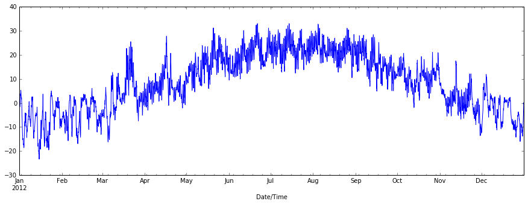

```python
weather_mar2012[u"Temp (C)"].plot(figsize=(15, 5))
```

# 2.3 Plotting the temperature by hour of day

This one's just for fun -- we've already done this before, using groupby and aggregate! We will learn whether or not it gets colder at night. Well, obviously. But let's do it anyway.

```python
temperatures = weather_mar2012[[u'Temp (C)']].copy()
print(temperatures.head)
temperatures.loc[:,'Hour'] = weather_mar2012.index.hour
```

[output not shown]

[output cut: 10 more lines]

```
2012-12-31 11:00:00      -6.7
2012-12-31 12:00:00      -5.8
2012-12-31 13:00:00      -4.6
2012-12-31 14:00:00      -3.4
2012-12-31 15:00:00      -2.3
2012-12-31 16:00:00      -1.4
2012-12-31 17:00:00      -1.1
2012-12-31 18:00:00      -1.3
2012-12-31 19:00:00       0.1
2012-12-31 20:00:00       0.2
2012-12-31 21:00:00      -0.5
2012-12-31 22:00:00      -0.2
2012-12-31 23:00:00       0.0

[8784 rows x 1 columns]>
```

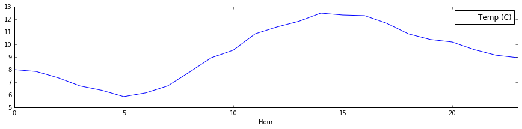

```python
temperatures.groupby('Hour').aggregate(np.median).plot()
```

So it looks like the time with the highest median temperature is 2pm. Neat.

# 5.4 Saving to a CSV

It's slow and unnecessary to download the data every time, so let's save our dataframe for later use!

```python
weather_2012.to_csv('../data/weather_2012_new.csv')
```

And we're done!